Cassy v3.87.0Release report · Published 28 October 2026 · 5:57 PM ET

# Commander stays connected and makes the work readable.

27 changes shipped across 4 areas; Commander has the most, 11.

One dot, one shipped change. No GitHub issues are counted in this report's fixes ledger.

See every change ↓

## Release at a glance

01 / 06

**What shipped, by area**

One dot is one titled CHANGELOG change. Section headings group changes; dots do not measure size or importance.

[output not shown]

Source: CHANGELOG `CHANGELOG.md`, release-notes draft `docs/release-notes/2026-10-28-v3.87.0-slack.md`, GitHub `Richards-LLC/cassy` release v3.87.0; retrieved 28 October 2026 · 6:07 PM ET.

27Changes shipped

14 fixed, 4 added, 9 changed; titled entries, not group headings

30m 11sGreen to published

Over the 20-min budget; merge-queue CI completion to publication

29m 39sMain to published

Over the 20-min budget by 9m 39s; main landing to published release

17 minSecond queue run

Within the 30-min budget; re-queue to successful landing, minute-rounded handoff

Changes and GitHub issues are counted separately. A change is one titled entry in the v3.87.0 CHANGELOG section; tests and documentation entries are listed under the hood but not counted. A GitHub issue counts when release PR #1422 or the CHANGELOG section references it and it closed between the PR opening (4:22 PM ET) and 15 minutes after its merge (5:43 PM ET). Issues are closed by hand shortly after the merge, so a report run inside that window waits for referenced issues that are still open. No GitHub issues are counted in this report's fixes ledger. The final publication receipt contains no per-stage blocker or intervention records. The release timeline includes a queue ejection at 4:38 PM ET, one repair cycle and re-queue at 5:10 PM ET; those precede the final publication interval and are not a zero-intervention claim for the whole release. Not measured for this release: request to published, cut to published, lesson recurrence.

## What you can do now

02 / 06

01

### Stay connected and know what happened

#### Steadier connections

WasCommander could flicker between connected and disconnected or stay waiting after your machine recovered.

NowSlow background reads do not hold up connection checks, and recovery retries stay bounded.

#### Honest status

WasA machine starting up could look broken, and refused access could leave Working on.

NowStartup says Connecting; lost or refused access clears Working.

#### A clear ending

WasLeaving with /exit could leave a stale work panel.

NowA dated Session ended receipt tells you what stopped and what is still running.

#### Your messages stay yours

WasTerminal-typed messages could appear late, and a message already received could still say Not confirmed.

NowTerminal input appears in order, and sent messages retain their own identity through reload and replay.

02

### Find the work and read it comfortably

#### Project navigation

WasSessions were a flat list with little context.

NowProject cards, Needs you, machine filters and reported account details help you find the right conversation. Before/after screenshots compare project grouping.

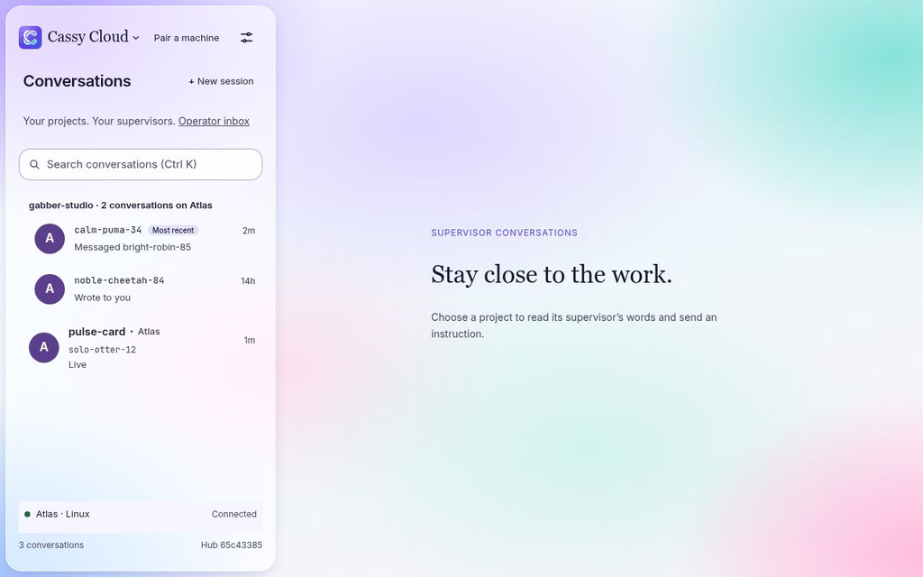

Before

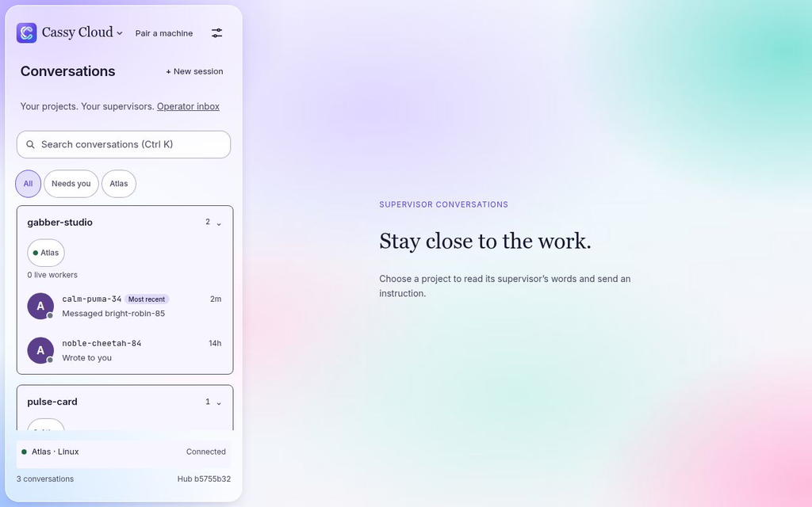

After

#### Release progress

WasA narrow panel dumped the whole task board beside unavailable buttons.

NowRead merged progress, current work and tasks that need you. All tasks opens the wider board; permission guidance folds into one line.

#### Room to read

WasThe progress panel stayed narrow and phone feedback could cover a task.

NowResize by dragging or keyboard, keep your chosen width, and read phone feedback without overlaps. Scrollbars match your theme.

#### Readable replies

WasTable words broke into single letters and headings and warnings blended together.

NowTables wrap whole words and formatting, headings keep their levels, and notes and warnings stand out.

#### Code and files

WasCopying code meant selecting it, previews sat apart from files and sent pictures became paths.

NowCode has Copy and Wrap. Files stay with their previews; your sent pictures remain thumbnails after reload, including on another device. Before/after screenshots compare the code frames.

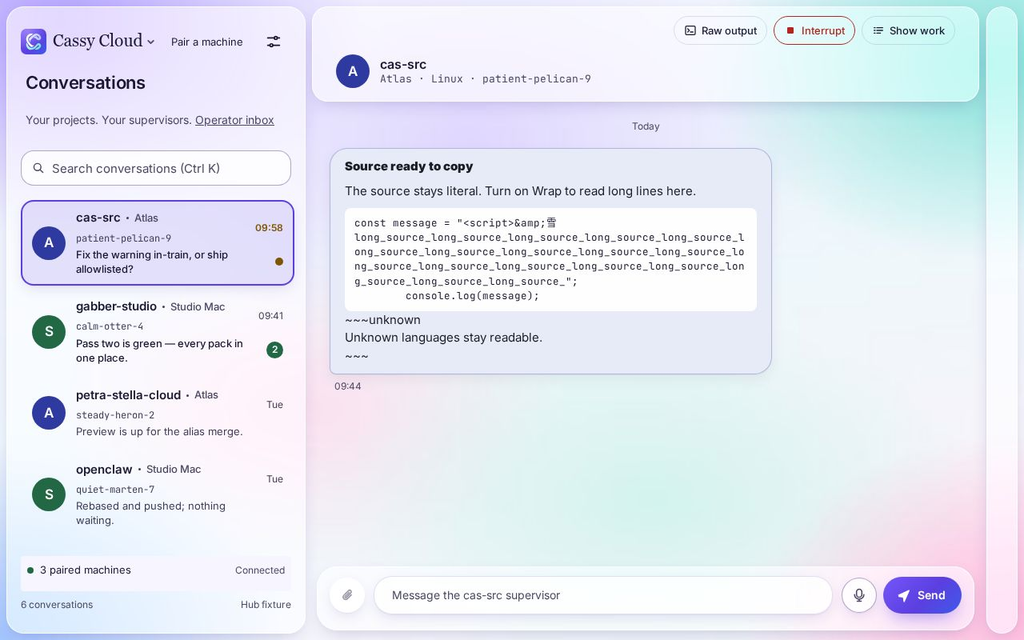

Before

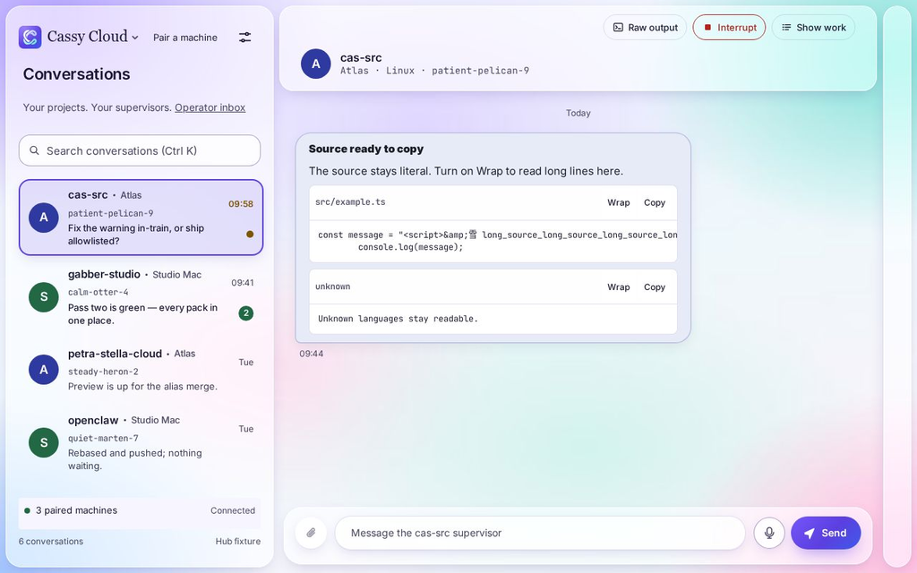

After

#### Preview recovery

WasA failed picture could leave an empty panel and stay failed.

NowFailures are compact and retry after reconnect.

03

### Accounts, Macs and updates

#### Account choices

WasThe picker made capacity hard to compare and could lose text typed ahead.

NowWeekly usage leads each usable account's row, recommendations are clear, and typed answers keep their normal meaning.

#### Claude and Mac support

WasClaude usage came from a direct private request, and valid Mac logins could be refused.

NowUsage comes from Claude's own tool, Mac credentials are recognized consistently and startup handoffs stay compact.

#### The hosted app stays current

WasA runtime release did not update hosted Commander.

NowPublication deploys its released Commander bundle automatically.

## Under the hood

03 / 06

01

### Hub and Commander

#### Recovery

WasSlow subscription and catalog work blocked health checks and recovery churn shared retry pressure.

NowHealth and interactive service are isolated, sessions retain independent backoff and outage recovery is bounded.

#### Measured recovery

WasA dropped connection could leave stale state waiting.

NowThe measured check detects the drop in about 2 seconds and recovers in about 4 seconds; this is a measured check, not a network-wide guarantee.

#### Auth persistence

WasRequests repeatedly parsed and rewrote accumulated connection tickets and synchronously appended audit data.

NowTicket pruning, cached identity reads and batched rotating audit writes reduce contention while retaining revocation checks and capability compatibility.

#### Measured store size

Was7.96 MB.

Now88 KB in the recorded comparison.

#### Measured lock-wait p95

Was504 ms.

Now0.07 ms in that comparison.

#### Session truth

WasEnded identity vanished during teardown, terminal capture could lag completion and durable sends lost their client reference.

NowGeneration-bound exit receipts survive cleanup, terminal input orders by input time and durable history correlates the original client reference before text.

#### Scoped progress

WasThe project-wide epic catalog was treated as session ownership.

NowHeader and task groups share an open, pinned-first or owner-based filter, matching names and registration IDs. Optional verification ownership is carried on the wire; All tasks remains explicit.

#### Rich chat

WasProse tables collapsed columns, split messages damaged fenced code and status folding could consume code-shaped replies.

NowWord-aware tables render inline formatting, code frames preserve source with Copy and Wrap, and headings and callouts keep their semantics.

#### Attachments and work detail

WasPreview failures stayed cached and sent uploads exposed host paths; background command output could disappear.

NowSession-bound previews recover on reconnect, sent uploads hydrate across devices and typed work facts retain background-command outcomes with legacy fallback.

02

### Runtime and delivery correctness

#### Official Claude usage

WasSubscription credentials were used for a direct private usage request.

NowCapacity is consumed only from the official binary's native statusline output.

#### Account input and portability

WasPicker buffers crossed prompt boundaries, profile spelling affected Keychain lookup and push checks used GNU-only commands.

NowBuffered input retains terminal editing and EOF semantics, profile paths normalize and readable Mac credentials work, and distribution checks are portable.

#### Startup and help

WasCodex startup emitted raw context or invalid hook output; help could require a default Claude login and empty Codex homes propagated.

NowNative startup produces compact valid handoffs, help parses first and empty homes are unset.

#### Close and review identity

WasAccumulated branch changes, stale tips or competing proof pointers could misclassify a delivery.

NowActual attributed commits and explicit final receipts govern classification; independent evidence, renamed paths, accepted drops and identical-tree repairs keep their identities.

#### Notifications and state

WasBackground review dispatch could expire silently, later transitions could swallow completion relays and routine reads repeated settled bodies.

NowDispatch is delivered, durable relays survive transitions, delayed notices are labelled and recipient projections retain intent without replaying settled content.

#### Artifacts and diagnostics

WasPeer artifact retrieval depended on local lookup, and partial issue queries or schema errors could yield misleading doctor results.

NowVisible Cloud metadata resolves committed evidence, authenticated metadata reads refuse redirects, and diagnostics retain partial results with explicit unavailable states.

#### Local safety and cleanup

WasLiteral clipboard text could trip policy guards, expanding heredocs escaped inspection and retired-cache scans depended on a global budget.

NowLiteral and expanding bodies are distinguished, missing bodies fail closed, memory writes stay bound to the active profile/project and known retired caches can be reclaimed while preserving proof.

#### Process ownership and checks

WasCleanup could miss child processes, resumed sessions lost server ownership and push checks could inspect the wrong checkout.

NowProcess-tree cleanup and resumed ownership are retained; checks bind to the pushed branch and accept named CommonJS browser cases.

#### Hosted deployment

WasRuntime publication left the hosted web build behind and transient promotion checks could roll back a healthy deployment.

NowPublication deploys its released bundle, pins the deployment CLI, removes the GitHub token from its environment and retries the live read before rollback.

## Fixes ledger

04 / 06

GitHub issues closed with this release · 0

| Issue | Title | Closed | Area |
| --- | --- | --- | --- |

No GitHub issues are counted in this report's fixes ledger.

## Install

05 / 06

```
cas update --yes --version 3.87.0
```

Release assets

| Asset | Digest | Size |
| --- | --- | --- |
| cas-aarch64-apple-darwin.tar.gz | sha256:6ff6ae02496232cdcc1ad117edb93b29499e40709dc13f475f877caebeef0cc2 | 37614942 |
| cas-x86_64-unknown-linux-gnu.tar.gz | sha256:6a685ee78c7dfd8157b9dadce0fc47fe0afa53b5c31b9e0f24ed21769e4f4864 | 42238906 |
| hub-deployment.json | sha256:5df690b99eea79d51933c2fecb2102b8b857ed6ec6338f30e06c68a5cfea63f8 | 643 |

## Evidence and scope

06 / 06

Retrieved: 28 October 2026 · 6:07 PM ET.

Source: CHANGELOG `CHANGELOG.md`, release-notes draft `docs/release-notes/2026-10-28-v3.87.0-slack.md`, GitHub `Richards-LLC/cassy` release v3.87.0; retrieved 28 October 2026 · 6:07 PM ET.

Release PR: [release pull request](https://github.com/Richards-LLC/cassy/pull/1422) (merged 28 October 2026 · 5:28 PM ET).

Release-notes draft: `docs/release-notes/2026-10-28-v3.87.0-slack.md`.

CHANGELOG source: `CHANGELOG.md`.

GitHub release: [v3.87.0 downloads](https://github.com/Richards-LLC/cassy/releases/tag/v3.87.0) (published 28 October 2026 at 5:57 PM ET).

Release receipt (relative to `~/.cas/artifacts`): `cassy-bbb8e75581403d3edc2689512df64eaf37780d70a032cb0d79850218dfada14a/cas-784a/latency/release-latency.receipt`.

### Publication timing

The official receipt starts at queue green 5:27:42 PM ET, then main landed 5:28:14 PM ET and publication finished 5:57:53 PM ET. Green to published is 30m 11s; main to published is 29m 39s. Both exceed the 20-minute publication budget; the release is already live and the overrun is recorded honestly.

### Capture and counting scope

The release-range lookup returned 8 complete verified pairs and 135 findings for other evidence. Only two matching desktop-light pairs are used: project grouping and code frames. The remaining changes have no image here; no side was fabricated or reconstructed.

The change map counts 27 bold titled CHANGELOG entries, not its 7 section headings. GitHub issue counts and their closure window remain the generator's official-query result, unchanged.

Stage timings are unavailable: the latency receipt records no STAGE_SECS.

Source note: grouped CHANGELOG headings required manual entry counting; tracked as cas-711a. Pair PNGs exceeded the finalizer image budget; their existing matching JPG captures are embedded instead.